# library_explore

Lucius Bynum

9/21/2017

# Honnold Wireless Data

## Data Dictionary

- MACID: (hashed) a unique id every network device has. 50:CC:F8:80:39:4D is my (old) cellphone
- UUID: (hashed) a unique hashed user id
- Campus: 7C campus abbreviations, e.g. HMC
- Device Name: name given to the wireless access point: CUC-HON-1-N-CAFE
- Folder: Like Name, a hierarchical representation of the access point used in the configuration: Top > CUC > Honold Mudd Library > First Floor
- Device Location: Text description of the location: Honnold Cafe
- Connect Year: year in which a connection was initiated: 2016
- Connect Month: month in which a connection was initiated: 1
- Connect Day: day in which a connection was initiated: 3
- Connect Hour: hour in which a connection was initiated (24h): 15
- Connect Day of Week: number of the day in week in which a connection was initiated: 6
- Connect Day of Year: number of the day in year in which a connection was initiated: 3
- Total Traffic (MB): megabytes of data that passed through the connection: 23.56
- AOS: text description of the mobile device’s operationg system: OS X Manufacturer: the name of the device manufacturer: Apple

# Preprocessing

```r
wireless <- preprocess_wireless_data()
# separate into numeric and non-numeric
numeric_data <- select_if(wireless, is.numeric)
non_numeric_data <- select_if(wireless, is.character)
summary(wireless)
```

```
##     campus             folder            location          connect_year
##  Length:343390      Length:343390      Length:343390      Min.   :2016
##  Class :character   Class :character   Class :character   1st Qu.:2016
##  Mode  :character   Mode  :character   Mode  :character   Median :2016
##                                                           Mean   :2016
##                                                           3rd Qu.:2016
##                                                           Max.   :2016
##  connect_month    connect_day     connect_hour   connect_minute
##  Min.   : 6.00   Min.   : 1.00   Min.   : 0.00   Min.   : 0.00
##  1st Qu.: 9.00   1st Qu.: 7.00   1st Qu.:12.00   1st Qu.:14.00
##  Median :11.00   Median :13.00   Median :15.00   Median :29.00
##  Mean   :10.44   Mean   :14.92   Mean   :14.91   Mean   :29.21
##  3rd Qu.:12.00   3rd Qu.:23.00   3rd Qu.:18.00   3rd Qu.:45.00
##  Max.   :12.00   Max.   :31.00   Max.   :23.00   Max.   :59.00
##   connect_dow     connect_doy    disconnect_month disconnect_day
##  Min.   :0.000   Min.   :178.0   Min.   : 7.00    Min.   : 1.00
##  1st Qu.:1.000   1st Qu.:272.0   1st Qu.: 9.00    1st Qu.: 7.00
##  Median :2.000   Median :308.0   Median :11.00    Median :13.00
##  Mean   :2.659   Mean   :302.6   Mean   :10.44    Mean   :14.91
##  3rd Qu.:4.000   3rd Qu.:337.0   3rd Qu.:12.00    3rd Qu.:23.00
##  Max.   :6.000   Max.   :365.0   Max.   :12.00    Max.   :31.00
##  disconnect_year disconnect_hour disconnect_minute duration_mins
##  Min.   :2016    Min.   : 0.00   Min.   : 0.00     Min.   :    0.0
##  1st Qu.:2016    1st Qu.:12.00   1st Qu.:14.00     1st Qu.:   10.0
##  Median :2016    Median :15.00   Median :29.00     Median :   20.0
##  Mean   :2016    Mean   :14.45   Mean   :29.08     Mean   :  124.9
##  3rd Qu.:2016    3rd Qu.:18.00   3rd Qu.:44.00     3rd Qu.:   74.0
##  Max.   :2016    Max.   :23.00   Max.   :59.00     Max.   :67959.0
##      bytes             bytesIn            bytesOut          AvgSigDBM
##  Min.   :    0.00   Min.   :    0.00   Min.   :    0.00   Min.   :-97.00
##  1st Qu.:    0.00   1st Qu.:    0.00   1st Qu.:    0.00   1st Qu.:-75.94
##  Median :    0.00   Median :    0.00   Median :    0.00   Median :-66.63
##  Mean   :   61.75   Mean   :   52.32   Mean   :    9.43   Mean   :-59.76
##  3rd Qu.:    9.19   3rd Qu.:    6.64   3rd Qu.:    1.39   3rd Qu.:-54.16
##  Max.   :74012.51   Max.   :46781.97   Max.   :37187.75   Max.   :  0.00
##    avgSigQual        SSID              OSdev
##  Min.   : 0.00   Length:343390      Length:343390
##  1st Qu.: 5.00   Class :character   Class :character
##  Median :24.00   Mode  :character   Mode  :character
##  Mean   :21.61
##  3rd Qu.:33.00
##  Max.   :71.00
##  start_datetime                stop_datetime
##  Min.   :2016-06-26 09:44:00   Min.   :2016-07-31 02:17:00
##  1st Qu.:2016-09-28 13:55:15   1st Qu.:2016-09-28 15:13:00
##  Median :2016-11-03 22:04:00   Median :2016-11-04 00:29:30
##  Mean   :2016-10-29 06:25:29   Mean   :2016-10-29 08:30:22
##  3rd Qu.:2016-12-02 16:48:45   3rd Qu.:2016-12-02 19:09:00
##  Max.   :2016-12-30 14:23:00   Max.   :2016-12-31 00:32:00
```

# Group By Day

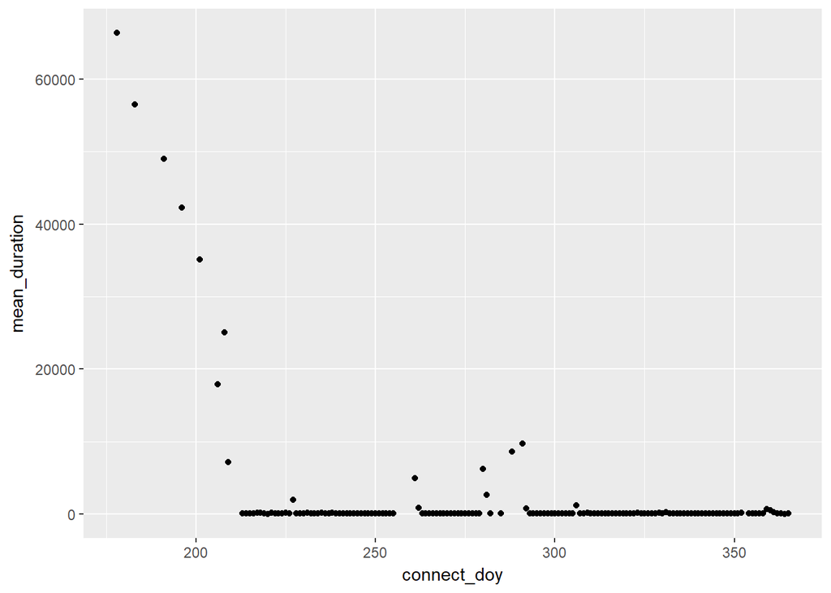

```r
duration_by_day <- wireless %>%
  group_by(connect_doy) %>%
  summarize(mean_duration = mean(duration_mins))

ggplot(duration_by_day, aes(x = connect_doy, y = mean_duration)) + geom_point()
```

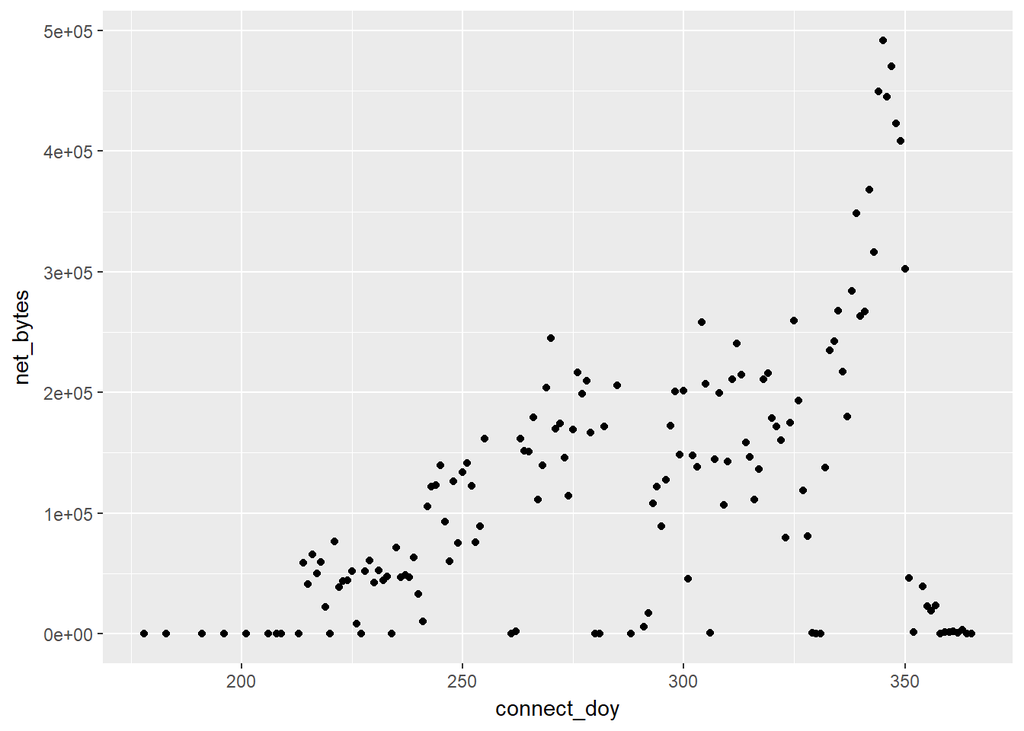

```r
usage_by_day <- wireless %>%
  group_by(connect_doy) %>%
  summarize(net_bytes = sum(bytesIn))

ggplot(usage_by_day, aes(x = connect_doy, y = net_bytes)) + geom_point()
```

# EZProxy Data

## CCL (EZProxy Report) Data Dictionary

- hashed user id: a unique identifier for a user e.g. * f7cbed2a86c711b4e28d13f74c40acf9f2a85a61db354bd8aa22dd1f944735c8
- campus: e.g. pomona
- session start datetime: e.g. 2016-07-07 15:39:24
- session end datetime: e.g. 2016-07-07 18:57:32
- session id: a unique identifier per ezproxy session e.g. oXFj5X88FvnsWrI
- ip address: (subnet only) e.g. 66.17.192

## SPU Data Dictionary

- session: unique session id. foreign key for report
- scheme: typically the transport protocol, e.g. http
- subdomain: aka host, e.g. ‘www’
- domain: often the name of the service, e.g. lexisnexis
- tld: The final portion of a Uniform Resource Locator, e.g. ‘com’
- path: file path to the requested resource
- query: often the requested resource, or if there’s a search query it should be here
- fragment: leftovers, e.g. preferences, tracking crap, etc.

### IP Address Subnets at Claremont

134.173.* belong to the Claremont Colleges.

The third octet values are assigned as follows:

- 8-15 Claremont SSID Wireless
- 24-31 Claremont SSID Wireless
- 32-63 HMC
- 64-95 Pomona
- 96-103 KGI
- 112-123 Pitzer
- 124-127 CUC - Legacy
- 128-135 CUC
- 140-141 Keck Science
- 144-159 Scripps
- 160-191 CMC
- 192-223 CINE Wireless
- 224-239 CGU
- 244-245 VPN Interior (non-Administrative)

```r
ezproxy <- preprocess_ezproxy_data()
head(ezproxy)
```

```
##           session scheme subdomain    domain tld
## 1 PuZfnR3YxIWrnb9   http       www     jstor org
## 2 uFlQeVBPsF3X9hI   http     web.a ebscohost com
## 3 vv4J9rzjbz9zkfW   http    search  proquest com
## 4 I25rrujcK5ONjbC   http      muse       jhu edu
## 5 vv4J9rzjbz9zkfW   http    search  proquest com
## 6 vv4J9rzjbz9zkfW   http       www     jstor org
##                                                path
## 1                                   /stable/3177624
## 2 /ehost/ebookviewer/ebook/bmxlYmtfXzM3NTMzM19fQU41
## 3                                    /pais/advanced
## 4                      /cgi-bin/resolve_openurl.cgi
## 5                                    /wpsa/advanced
## 6                                          /openurl
##                                                                                                                                                                                                                                                query
```

[output cut: 34 more lines]